⌂ Lectures

← →/space · tap / swipe to advance · F fullscreen

DSAIT4090 · Natural Language Processing · 2026/2027

# Word Embeddings & Text Classification

Dense vector representations of text — vector-space models, softmax & cross-entropy, word2vec.

Where we were

# Last lecture: generating language

- **Statistical language models** — assign probability to text and **generate** new language given a prompt or prefix.
- **Tokenization** — decompose raw text into its basic units, **tokens**, so it can be processed.
- We gave words meaning through the **context** they appear in.

Where we are going

# This lecture: vectors that capture meaning

- How do we represent a word as a **vector**, so a machine-learning model can ingest it? (ML models eat vectors.)
- A new class of task: not *generating* text, but **classifying** it — we grow our repertoire.

The plan **Vector-space models** & cosine similarity → **text classification with neural networks** (differentiable machines: softmax & cross-entropy) → **word embeddings** that marry context with the vector → **text classification** with embeddings.

Part I

# Representing text as vectors

One-hot and bag-of-words, and comparing two texts with cosine similarity.

The simplest vector space

# One dimension per token

[figure not shown]

The simplest vector space gives **every token its own dimension** (one-hot). A document is then just **word counts** — **order is lost** (the reversed headline gives the same vector), and the vector is **huge and sparse**: |V| = 22 here, but 200,019 dimensions with the GPT-4o tokenizer, almost all zero.

Comparing two pieces of text

# Cosine similarity

How similar are two texts? Turn each piece of text into a vector, then compare them by the **angle** between them.

$cos(a,b) = a · b‖a‖ ‖b‖ ∈ [−1, 1]$

| “telescope finds water on a distant planet” | vs | “astronomers spot water on a faraway world” | cos ≈ 0.82 |
| --- | --- | --- | --- |
|  | vs | “parliament votes on the new climate bill” | cos ≈ 0.11 |

**Why cosine, not the raw dot product?** the dot product grows with vector *length*, so a longer document would look “more similar” just for being long. Cosine divides that out and compares **direction** only.

Part II

# Softmax and cross-entropy

The classification machinery: scores → probabilities → a loss → a gradient. We reuse it for word2vec.

Question

Given a piece of text, how do we **classify** it into one of a fixed set of classes — *science, politics, sports, movies*?

A neural network reads the text and must output a decision. It turns out to be a two-step recipe: **softmax** then **cross-entropy**.

**Think** — then → for the pieces.

Step 1 · the network's output

# A classifier outputs raw scores

The classifier reads the sentence vector **x**; a neural net **f<sub>θ</sub>** produces one number per class. These raw outputs are the **logits**.

[figure not shown]

A **logit** is just a raw score — any real number, even negative, not yet a probability. Softmax (next) turns them into probabilities. The same network reappears on every slide in this part.

Scores → probabilities

# Softmax

p<sub>i</sub> = e<sup>s<sub>i</sub></sup>  
∑<sub>j</sub> e<sup>s<sub>j</sub></sup> (exponentiate, then normalise)

[figure not shown]

Same network — now the output layer is passed through softmax: exponentiate (every value positive), then divide by the total (11.58). A distribution that sums to one.

Sharpen or flatten

# Temperature

p<sub>i</sub> = e<sup>s<sub>i</sub>/T</sup>  
∑<sub>j</sub> e<sup>s<sub>j</sub>/T</sup>

[figure not shown]

Same logits, divided by **T** before softmax. Low **T** (0.3) sharpens (science → 0.96); high **T** (3) flattens (science → 0.38) — the LLM sampling knob.

Measuring the error

# Cross-entropy

ℒ = −∑<sub>i</sub> y<sub>i</sub> log p<sub>i</sub> = −log p<sub>true</sub> = −log 0.64 ≈ 0.45

[figure not shown]

The truth is **one-hot** (green ring = true class), so only the probability on the right answer counts. **Why the log?** a confident right answer costs almost nothing; a confident mistake costs without bound.

From loss to gradients

# The gradient is p − y

|  | p<sub>j</sub> | y<sub>j</sub> | p<sub>j</sub>−y<sub>j</sub> |  |
| --- | --- | --- | --- | --- |
| **Science** | 0.64 | 1 | −0.36 | raise |
| **Politics** | 0.23 | 0 | +0.23 | lower |
| **Sports** | 0.10 | 0 | +0.10 | lower |
| **Movies** | 0.03 | 0 | +0.03 | lower |

∂ℒ/∂s<sub>j</sub> = p<sub>j</sub> − y<sub>j</sub> , θ ← θ − η ∇ℒ

Backprop carries **p − y** to every weight; after one step science rises 0.64→0.75 and the loss falls 0.45→0.29.

Using the trained model

# Inference · the prediction

Frozen forward pass Weights frozen; one forward pass, no labels, no loss, no gradients — the highest probability wins.

[figure not shown]

“parliament votes on the new climate bill” → f<sub>θ</sub> → logits → softmax → **politics 0.91**: the **argmax** is the decision.

Part III

# Word embeddings: word2vec

The problem with sparse vectors, what we need instead, and how word2vec learns dense, meaning-bearing vectors — reusing the softmax & cross-entropy of Part II.

Why we need better vectors

# The problem with sparse one-hot vectors

- **Every pair is orthogonal** — *hotel* and *motel* share no dimension, so they look as unrelated as *hotel* and *cat*.
- **Huge & sparse** — vectors as wide as the vocabulary (up to millions of dims), almost all zeros.
- **No shared evidence** — a classifier must learn *every* word on its own; seeing “planet” in training teaches it nothing about “moon”.

(w<sup>hotel</sup>)ᵀ w<sup>motel</sup> = (w<sup>hotel</sup>)ᵀ w<sup>cat</sup> = 0

**Why this hurts prediction:** if related words had **similar vectors**, a classifier could **generalise** — evidence for “planet” would transfer to “moon”. One-hot blocks exactly that, so it needs far more data and still predicts poorly on words it saw rarely.

From local to distributed

# What we need: dense vectors that encode meaning

[figure not shown]

**Local (1-hot):** one active dimension per word — no shared structure. **Distributed:** meaning is spread across ~300 features, so similar words get **similar vectors** — and a classifier can **share evidence** across them, so **prediction accuracy improves**. How do we learn such vectors from text alone? →

The distributional idea

# Meaning from the company a word keeps

Firth, 1957 “You shall know a word by the company it keeps.” A word's **company** = every word within **±2 positions** of it, counted across a corpus of science & politics headlines.

|  | *a* | *distant* | *cold* | *new* | *climate* | *tax* |
| --- | --- | --- | --- | --- | --- | --- |
| planet | 2 | 1 | 1 | 0 | 0 | 0 |
| moon | 2 | 1 | 1 | 0 | 0 | 0 |
| bill | 0 | 0 | 0 | 2 | 1 | 1 |

Use each row of counts as the word's vector: cos(planet, moon) = 1.00 (identical company), cos(planet, bill) = 0.00. Nobody told the model planets and moons are related — meaning emerged from text alone. **But** the table still grows with the vocabulary and is mostly zeros → we want **short, dense** vectors.

Word2Vec · key idea

# A word is known by the company it keeps

The duck test “If it walks like a duck and quacks like a duck, it must be a duck.” The blanks share a **context**: like a __ and quacks · like a __ it must · be a __.

- Form **⟨word, context⟩ pairs** by sliding a window over the text.
- Learn vectors so a word **predicts** the words around it.
- Q: how do we turn “predict the context” into something trainable?

Manufacturing training data from raw text

# Skip-gram and CBOW: two ways to use the window

| window · **center** in bold | Skip-gram center → context | CBOW context → center |
| --- | --- | --- |
| **telescope** spots water | telescope→spots, telescope→water | {spots, water} → telescope |
| telescope **spots** water on | spots→telescope, →water, →on | {telescope, water, on} → spots |
| telescope spots **water** on a | water→telescope, →spots, →on, →a | {telescope, spots, on, a} → water |
| spots water **on** a | on→spots, →water, →a | {spots, water, a} → on |
| water on **a** | a→water, →on | {water, on} → a |

**Click** to slide the window position by position — the pairs accumulate. This one clause yields **14 skip-gram pairs** (center → each neighbour) or **5 CBOW examples** (neighbours → center). Over a corpus, raw text becomes millions of pairs — **no labels needed**. Skip-gram is our focus.

The whole model, as classification

# Word2vec is one big multi-class classifier

[figure not shown]

The one-hot center word selects a **row of E** — its embedding **v** (the bottleneck). We score **v** against **every column of U** (one output vector per word) and **softmax over the whole vocabulary**: one class per vocabulary word, and the true neighbour *spots* should win. The same softmax & cross-entropy as Part II — scaled to |V| classes.

Input vs. output embeddings

# Word2vec learns two matrices

[figure not shown]

**E** holds a vector for each word as a **center** word; **U** a second vector for each word as a **context** word — both vocab × d (here d = 2). To score one pair: look up **v<sub>water</sub>** (a row of E, e.g. (0.5, 0.2)); its score for context **c** is the dot product **u<sub>c</sub> · v<sub>water</sub>**. The input embeddings E are usually kept as the final word vectors.

How the parameters are learned

# Training with gradient descent

[figure not shown]

The skip-gram softmax Score a context word **c** by **u<sub>c</sub> · v<sub>w</sub>**, then softmax over the **whole vocabulary** — exactly the softmax of Part II, one class per word.

P(c | w) = e<sup>u<sub>c</sub> · v<sub>w</sub></sup>  
∑<sub>k∈V</sub> e<sup>u<sub>k</sub> · v<sub>w</sub></sup>

Loss is cross-entropy **ℒ = −log P(c | w)** for the real neighbour; the gradient w.r.t. the scores is again **p − y**. The **denominator** — a score over every word — is the expensive part.

Making softmax affordable

# Negative sampling

[figure not shown]

Why the denominator hurts

The softmax denominator sums over **all V words** — with V in the millions, every update is far too expensive.

**Negative sampling:** score the **true context word** against just a few k random “negative” words (real vs. fake). Draw negatives ∝ frequency<sup>3/4</sup>; k=5–20 (small data), 2–5 (large).

ℒ<sub>neg</sub> = −log σ(u<sub>o</sub> · v<sub>c</sub>) − ∑<sub>i=1</sub><sup>k</sup> log σ(−u<sub>i</sub> · v<sub>c</sub>)

A cheap **yes/no** question with σ — *real or fake?* — replaces “which of millions is the neighbour”. Only k+1 dot products, not V. (Google News word2vec: a 3M-word vocabulary.)

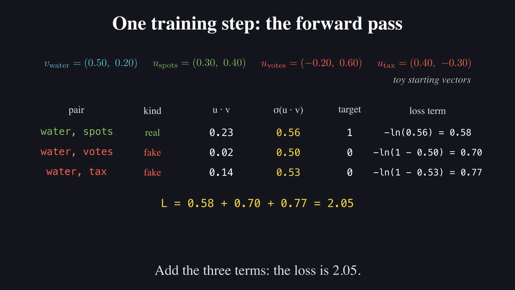

Forward: a dot product then σ for each pair. Untrained, all three σ ≈ 0.5 (coin flips); the three cross-entropy terms sum to loss **2.05**.

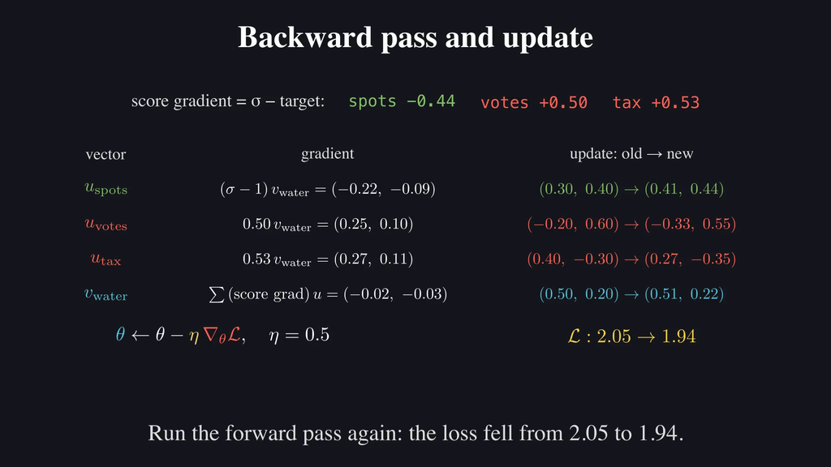

Backward: the score gradient is **σ − target = p − y**; by the chain rule it updates only 4 rows — *v<sub>water</sub>* (a row of E) and *u<sub>spots</sub>, u<sub>votes</sub>, u<sub>tax</sub>* (3 rows of U). One step with η = 0.5 pulls the real pair together and the fakes apart: loss **2.05 → 1.94**.

Watching it train

# The space organizes itself

[figure not shown]

Start from small random 2-D vectors (**before**) — loss **3.09 = ln 22**, exactly uniform guessing. Over **600 epochs** it falls to **2.24** (**after**): science drifts from politics, same-company words land together — *planet/moon*, *water/ice*, *parliament/senate* reach cosine **+1**, *planet/bill* point apart at **−0.85**. Nobody set these by hand — they fell out of a prediction task, and **E is just the first layer** of the network.

What the vectors capture

# The geometry of embeddings

Analogies become arithmetic Directions in the space encode relationships, so analogies can be solved by adding and subtracting vectors.

$vec(king) − vec(man) + vec(woman) ≈ vec(queen)$

- The *man → woman* direction is roughly the same as *king → queen*.
- Good embeddings are often **pre-computed** and freely available (e.g. via **gensim**).

Part IV

# Using embeddings, and their limit

Average a sentence's vectors to classify it — and why one static vector per word is not enough.

Documents → classes

# Text classification

[figure not shown]

Embed each document, then run the ordinary pipeline — **train data** → learning algorithm → **model** → predict the label (Physics · Chemistry · Maths) of a new document.

From words to documents

# Representing a whole document

Bag of word-vectors Each word is a vector. Represent a document as the **average** (or **sum**) of the vectors of the words it contains.

- Simple, fast, and surprisingly strong as a baseline document representation.
- Order is ignored — it is still a *bag* — but each dimension is now **semantic**, not a raw word count.
- Libraries such as **gensim** provide word2vec and these aggregations out of the box.
- Train the classifier with cross-entropy and gradient **p − y**; that gradient can even flow back into **E**, fine-tuning the embeddings for the task.

One word, one vector?

# The static limit

Polysemy breaks static embeddings

*spots* means **sees** in “telescope spots water” but **dots** in “a leopard's spots” — a static embedding gives both the **same vector**.

The fix: make a word's vector depend on its sentence — exactly what **attention** and contextual embeddings do (next lectures).

Wrap-up

# Summary

Take away

Words/texts become **vectors** (vector-space model), compared by **cosine similarity**.

**Softmax + cross-entropy** turn a vector into a decision and a loss; the gradient is **p − y**.

**word2vec** reuses that machinery as one big multi-class classifier, made cheap by **negative sampling**, to learn dense embeddings; analogies become arithmetic.

Average a sentence's embeddings to classify it. The **static limit** motivates contextual embeddings (attention).